# Linear regression

## Introduction

- Motivation
- Data assumptions
- Perform the linear regression analysis
- Model evaluation

## Prepare data

**fev** data: Smoking tends to impair lung function. Data in children who smoke.

**age**: subject age **smoke**: smoke smoking habits (1 = yes, 2 = no)

```r
#dataForAnalysis=read.csv("./data/fev.csv",header=TRUE,row.names=1)
dataForAnalysis <- read.csv("https://raw.githubusercontent.com/couthcommander/sip_computing/main/labs/fev.csv",header=TRUE,row.names=1)
dataForAnalysis$sex=ifelse(dataForAnalysis$sex==1,"male","female")
dataForAnalysis$smoke=ifelse(dataForAnalysis$smoke==1,"yes","no")

head(dataForAnalysis)
```

```
##   age   fev height    sex smoke
## 1   9 1.708   57.0 female    no
## 2   8 1.724   67.5 female    no
## 3   7 1.720   54.5 female    no
## 4   9 1.558   53.0   male    no
## 5   9 1.895   57.0   male    no
## 6   8 2.336   61.0 female    no
```

## Simple linear regression

**Question**: Does age associated with fev (lung function )?

### Data assumptions

**Normality**: dependent variable follows a normal distribution

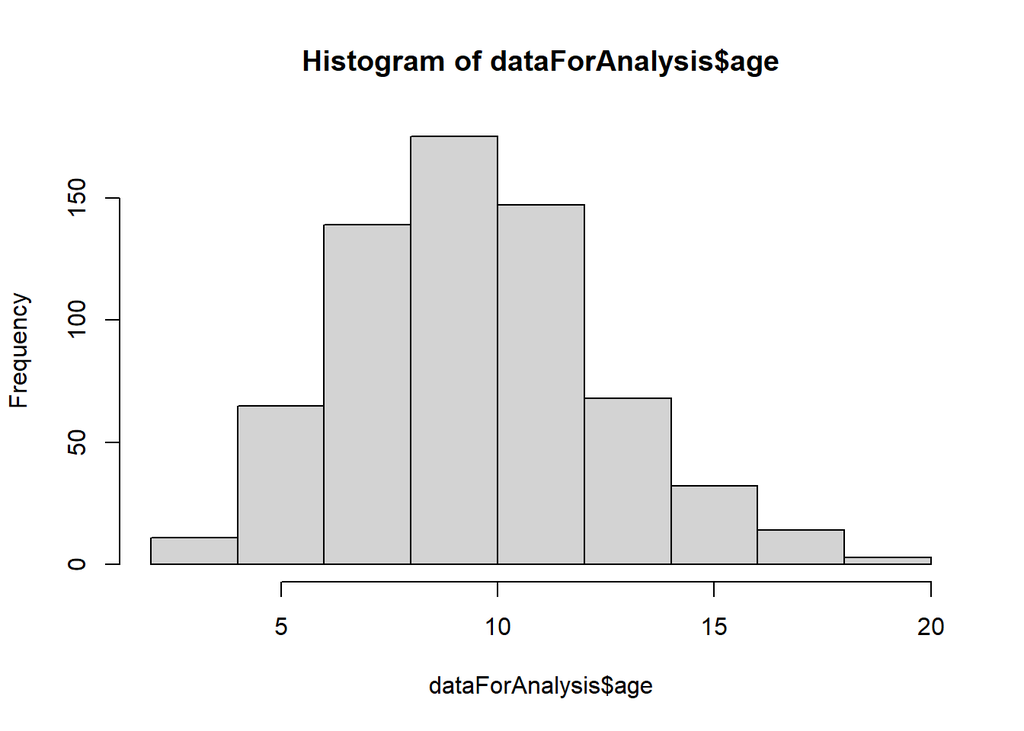

```r
hist(dataForAnalysis$age)
```

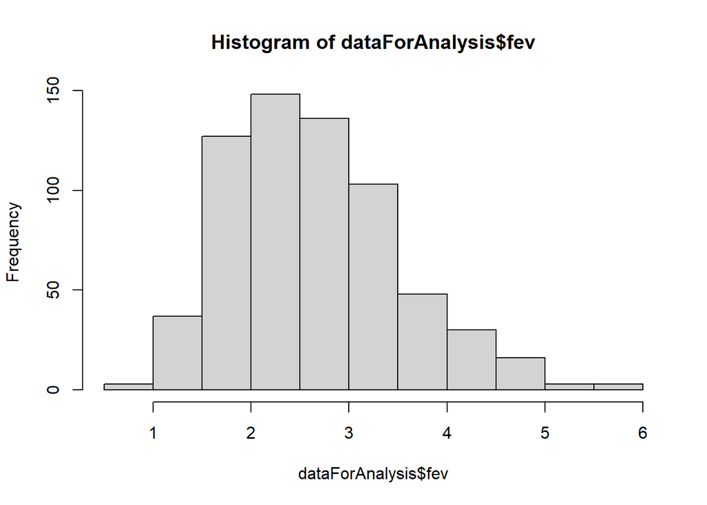

```r
hist(dataForAnalysis$fev)
```

**Linearity**: The relationship between the independent and dependent variable must be linear.

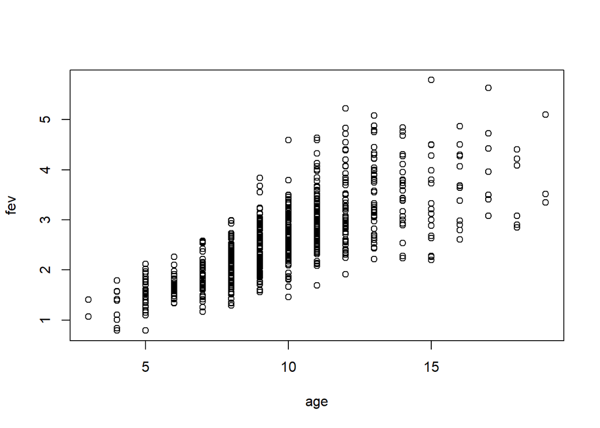

```r
plot(fev ~ age, data = dataForAnalysis)
```

### Perform the linear regression analysis

fev=b0+b1*Age

```r
modelResult <- lm(fev ~ age, data = dataForAnalysis)

summary(modelResult)
```

```
##
## Call:
## lm(formula = fev ~ age, data = dataForAnalysis)
##
## Residuals:
##      Min       1Q   Median       3Q      Max
## -1.57539 -0.34567 -0.04989  0.32124  2.12786
##
## Coefficients:
##             Estimate Std. Error t value Pr(>|t|)
## (Intercept) 0.431648   0.077895   5.541 4.36e-08 ***
## age         0.222041   0.007518  29.533  < 2e-16 ***
## ---
## Signif. codes:  0 '***' 0.001 '**' 0.01 '*' 0.05 '.' 0.1 ' ' 1
##
## Residual standard error: 0.5675 on 652 degrees of freedom
## Multiple R-squared:  0.5722, Adjusted R-squared:  0.5716
## F-statistic: 872.2 on 1 and 652 DF,  p-value: < 2.2e-16
```

Model Interpretation:

the *Coefficients* estimates of the beta coefficients, Intercept (b0)=0.431648 and age (b1)=0.222041

the standard errors (SE), which defines the accuracy of beta coefficients. For a given beta coefficient, the SE reflects how the coefficient varies under repeated sampling.

the t-statistic and the associated p-value, which defines the statistical significance of the beta coefficients.

the estimated regression equation can be written as follow: fev = 0.431648 + 0.222041*age

the intercept (b0) It can be interpreted as the predicted fev value at age zero.

the beta coefficient (slope) for age (b1) is 0.222041. It means with age increase in one year, the predicted fev value will increase 0.222041.

The R-squared (R2) ranges from 0 to 1 and represents the proportion of information in the data that can be explained by the model. For a simple linear regression, R2 is the square of the Pearson correlation coefficient.

The adjusted R-squared adjusts for the degrees of freedom.

### Model evaluation

#### Confidence interval of Coefficients

```r
confint(modelResult)
```

```
##                 2.5 %    97.5 %
## (Intercept) 0.2786920 0.5846042
## age         0.2072777 0.2368043
```

The standard error measures the variability/accuracy of the beta coefficients. It can be used to compute the confidence intervals of the coefficients. There is approximately a 95% chance that the interval [0.2072777, 0.2368043] will contain the true value of b1.

#### Visulization of the fitted line

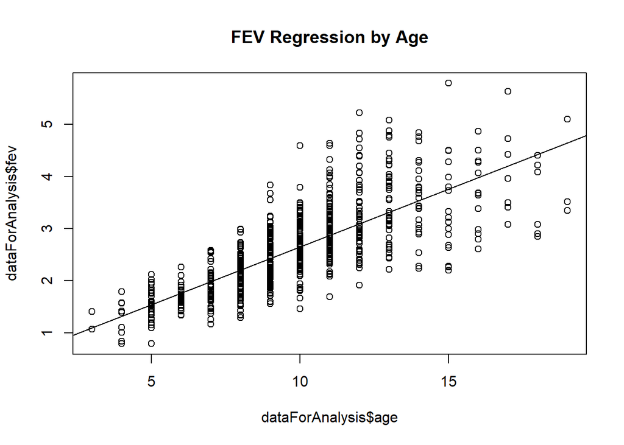

```r
plot(dataForAnalysis$age,dataForAnalysis$fev,main = "FEV Regression by Age")
abline(modelResult,cex = 1.3,pch = 16,xlab = "FEV",ylab = "Age")
```

#### Residuals distribution

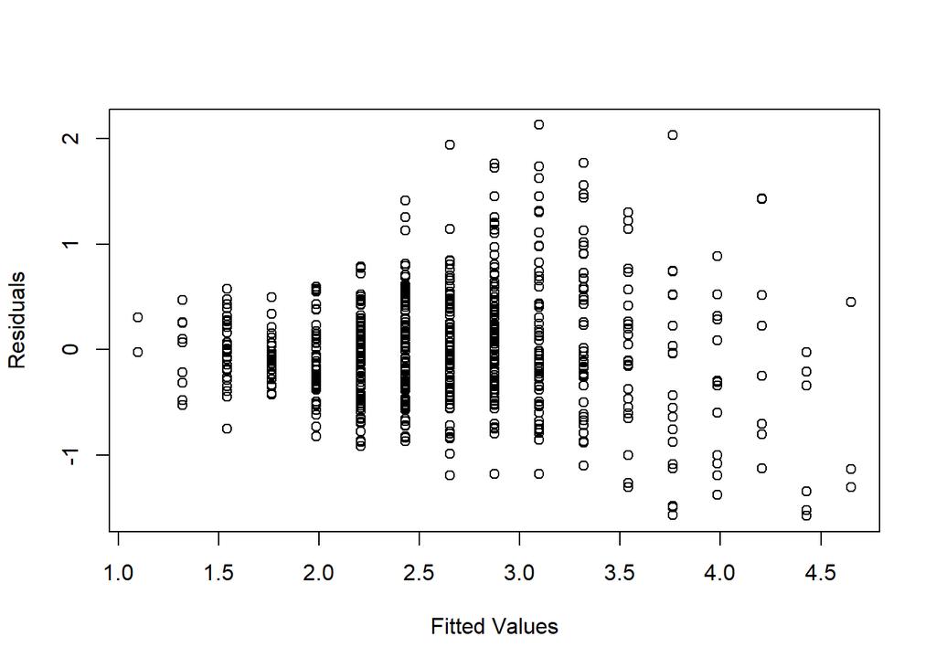

```r
plot(modelResult$fitted.values,modelResult$residuals,xlab="Fitted Values",ylab="Residuals")
```

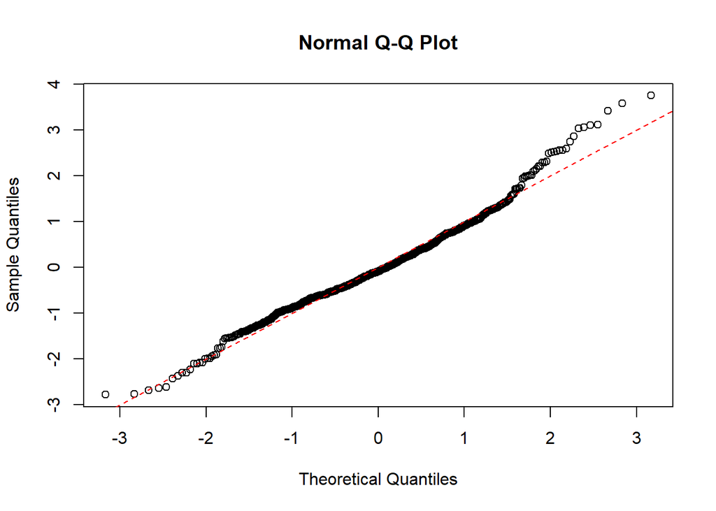

```r
qqnorm(scale(modelResult$residuals))
abline(0,1,lty=2,col="red")
```

### Predict new data

```r
newData <- data.frame(age = c(Subject1=3,Subject2=4))
predict(modelResult,newData)
```

```
## Subject1 Subject2
## 1.097771 1.319812
```

## Multiple linear regression

Multiple linear regression is an extension of simple linear regression used to predict an outcome based on multiple predictors.

**Question**: Are age and smoking associated with fev (lung function)?

### Data visulization

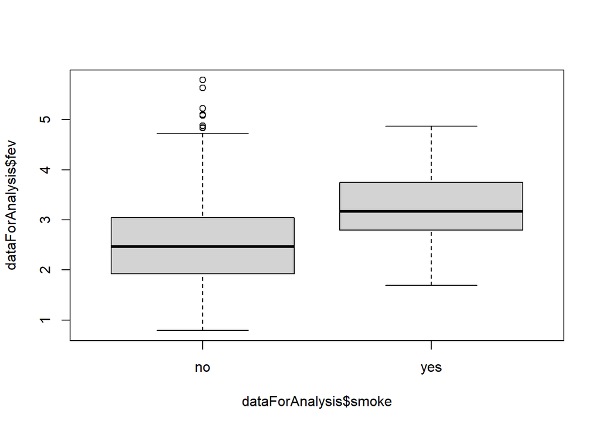

```r
boxplot(dataForAnalysis$fev~dataForAnalysis$smoke)
```

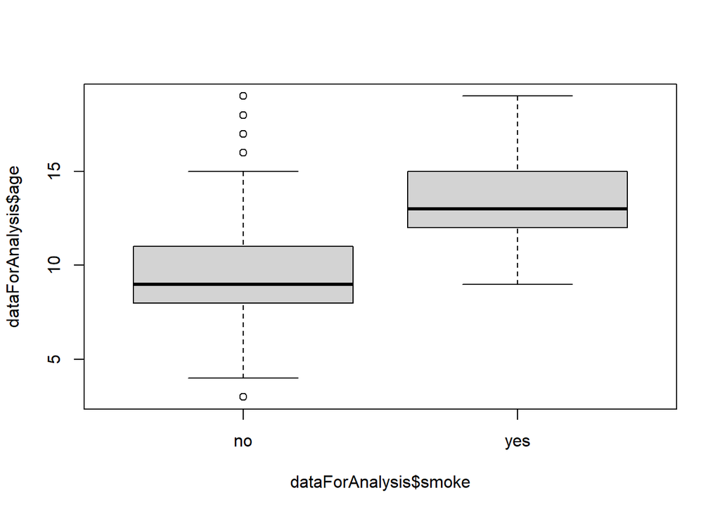

```r
boxplot(dataForAnalysis$age~dataForAnalysis$smoke)
```

### Perform the linear regression analysis

```r
modelResult <- lm(fev ~ age+smoke, data = dataForAnalysis)

summary(modelResult)
```

```
##
## Call:
## lm(formula = fev ~ age + smoke, data = dataForAnalysis)
##
## Residuals:
##     Min      1Q  Median      3Q     Max
## -1.6653 -0.3564 -0.0508  0.3494  2.0894
##
## Coefficients:
##              Estimate Std. Error t value Pr(>|t|)
## (Intercept)  0.367373   0.081436   4.511 7.65e-06 ***
## age          0.230605   0.008184  28.176  < 2e-16 ***
## smokeyes    -0.208995   0.080745  -2.588  0.00986 **
## ---
## Signif. codes:  0 '***' 0.001 '**' 0.01 '*' 0.05 '.' 0.1 ' ' 1
##
## Residual standard error: 0.5651 on 651 degrees of freedom
## Multiple R-squared:  0.5766, Adjusted R-squared:  0.5753
## F-statistic: 443.3 on 2 and 651 DF,  p-value: < 2.2e-16
```

```r
confint(modelResult)
```

```
##                  2.5 %      97.5 %
## (Intercept)  0.2074647  0.52728140
## age          0.2145336  0.24667553
## smokeyes    -0.3675476 -0.05044215
```

Model Interpretation:

the estimated regression line equation can be written as follow: fev = 0.367373 + 0.230605* age-0.208995*Smoke(Yes)

the beta coefficient for the variable age (b1) is 0.230605. It means with age increase in one year, the predicted fev value will increase 0.230605

the beta coefficient for the variable smoke (b2) is -0.208995. It means the predicted fev value will be smaller (-0.208995) in smokers.

F-statistic gives the overall significance of the model. It assess whether at least one predictor variable has a non-zero coefficient.

### Effects of variables

```r
library(effects)
```

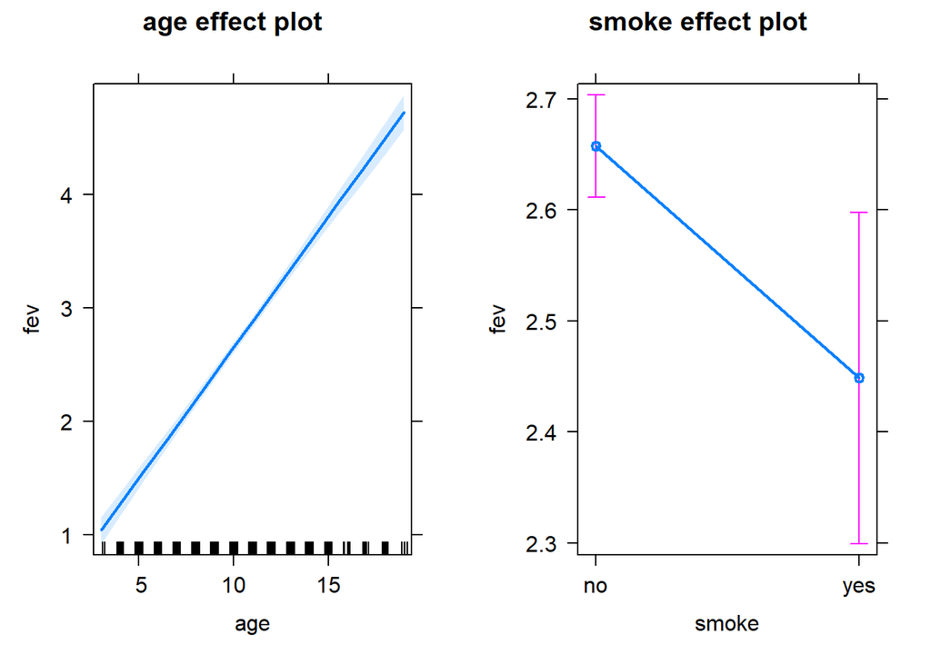

```r
plot(allEffects(modelResult))
```